# Workflow creating modflow6 model of the Wierden area

# 1 Creating Ugrid

Modflow 6 grid generation is based on Ugrid, which can be unstructured. Moreover, it is no longer necessary to have the same number of layers at every location. This means that for example local ice pushed ridges at and near the Holterberg can be assigned to his own locally present layers.

Setting up a Ugrid requires choosing which type of grid cells are required. Except for the original layering (rows, columns and layers) one could choose:

- Voronoi
- Quadtree
- Octree

We are using Quadtrees and using local refinement at the nature reserves (Wierdens veld, Mokkelengoor), the Regge and at the well locations. For the nature reserves and the Regge we are assiging “refinement” to their arc’s (and points if wells are concerned) with a specific refinement for the nodal distances.

## 1.1 Polygons, arcs and points

To create an unstructured grid with Quadtree/Octree refinement should be checked in the coverage where all polygons (whole domain of the model, Wierdense veld, Mokkelengoor), arcs (Regge) and points (Vitens’ wells) should be checked.

The general set up of this coverage would then be:

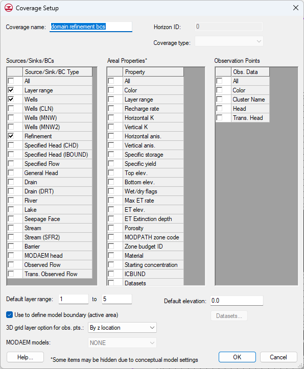

coverage setup Ugrid Wierden model

Be sure that the polygons are all polygons and not just connected arcs

The attribute table for the selected polygons should look like this:

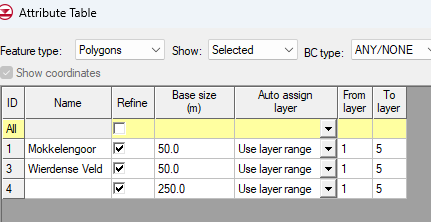

polygon refinement

The actual base size can be altered. Note ID 4 has no name but is the polygon of the whole domain.

The Regge (the only multi arc) should have similar refinement set. Actual refinement can be altered.

[figure not shown]

Refinement Regge arcs

Finally the nodes where the wells are located will receive a grid refinement.

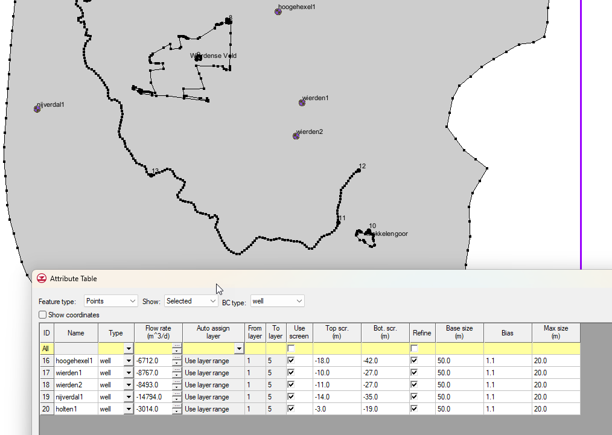

Refinement at wells

Note that, in this case, seem to have well type extraction rate and well screen “active” Forgot the uncheck wells but somehow at this stage it doesn’t matter..

Select the Grid Frame, fit it to the active coverage (i.e. the coverage with the domain and all the refinements and select UGrid

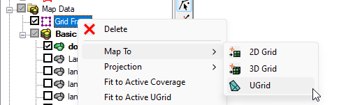

Ugrid selection

Set the following window should appear. Use the same settings.

[figure not shown]

Settings map to ugrid

This result in the following Ugrid:

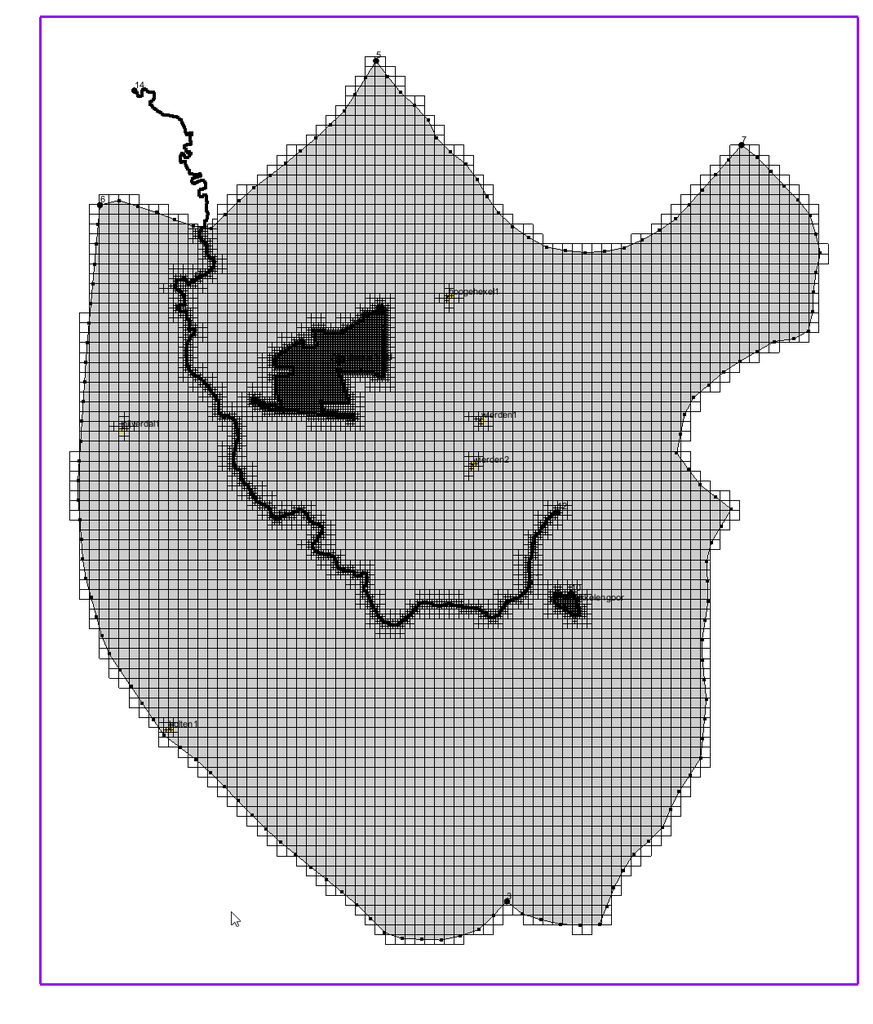

Ugrid of the Wierden model with various refinements

# 2 Creating a new MODFLOW6 simulation

To set up a new modflow 6 simulation several steps need to be taken;

1. Setting up a new modflow6 simulation
   1. Check all the required packages. Be aware that “IBOUND” is not available so “CHD” should be used instead
2. Assigning the layer elevations to the Ugrid layers
3. Assigning the all (GMS) coverage data to the model (CHD, DRN, RIV, WEL, RCH,..)
4. Run this new modflow6 model
5. Analyse the results
   1. heads
   2. flow budgets

## 2.1 Setting up a new modflow6 simulation

1. Create a new (mf6) simulation by right clicking in the explorer window and selection “New Simulation”

[figure not shown]

2. Select the appropriate packages

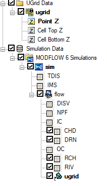

mf6 files and packages

## 2.2 Assigning the layer elevations to the Ugrid layers

Basic approach is to use 2D scatter data or rasters to interpolate these elevations to the Ugrid layers.

This approach is based on 2D scatter data which I created from the elevation TIN’s which originate from the raster files (*.tif files). Creating the 2D data sets from TIN’s is quite simple; Select each TIN, right-click and select “Convert To -> 2D Scatter Points;

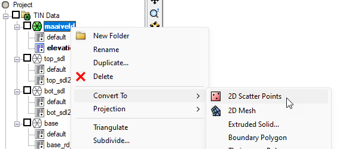

Convert TIN-data to 2D scatter points

Next, the 2D scatter points need to be interpolated to the Ugrid. For interpolation I use simply “linear”;

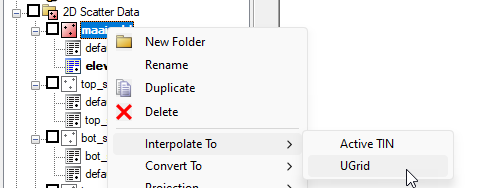

Interpolate 2D scatter to Ugrid (layers)

This results in the following elevations to the Ugrid;

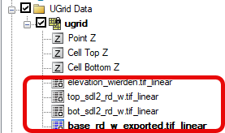

Elevations to Ugrid

### 2.2.1 Assigning the ugrid elevations 2 tops and bottoms

The elevations assigned to the ugrid are now ready to be mapped to the layer (3) elevations of the modflow6 model.

The following approach should do the trick;

1. Double click on the DISV (Vertex Grid Discretization) data set
2. Start with the Top elevations (already selected and dimmed) of the upper layer of the ugrid;

[figure not shown]

3. Select the surface elevations dataset

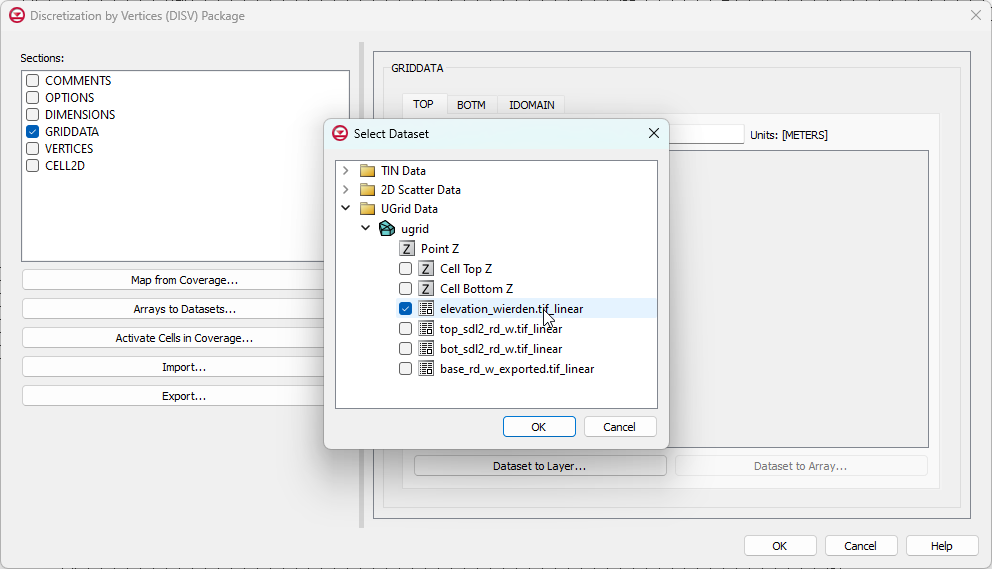

4. Select the bottom elevation set for ugrid layer 1

[figure not shown]